# STAT 687 - Chapter 3

Nonparametric Estimation

Maj Jason Freels

Air Force Institute of Technology

## This chapter explains:

STAT 687 - Chapter 3

- Statistical methods, based on the binomial distribution, to estimate $F(t)$ from interval & singly right-censored data, without assuming an underlying parametric distribution.
- Standard errors of the nonparametric estimator and approximate confidence intervals for $F(t)$.
- Methods to extend nonparametric estimation to allow for combinations of interval-censored & multiply right-censored data.
- The Kaplan-Meier nonparametric estimator for data with observations reported as exact failure times
- A generalized nonparametric estimator of $F(t)$ for arbitrary censoring

# Section 3.1|Introduction

## $\S$ 3.1 - Introduction

STAT 687 - Chapter 3

In reliability studies, it’s preferable to allow the data to speak for itself - before assuming a parametric distribution

Chapter 3 outlines methods to compute nonparametric estimates for

$\hat{F}(t), \hat{S}(t), se(\hat{F}(t))$

The goal will be to compute confidence intervals on our estimates that contain the true, but unknown, values with confidence level $1-\alpha$

First, we assume that the data are singly censored before extending to multiply censored data and then to data with arbitrary censoring

## $\S$ 3.1 - Introduction

STAT 687 - Chapter 3

**Nonparametric techniques:**

- Can be used when we don’t know the underlying distribution that governs the failure process that produced the data
- Are common in survivability (biostatistics and actuarial sciences)
- Are gaining traction in reliability studies
- Can simplify analyses by quickly revealing poor-fitting parametric models
- Can be used as a benchmark to compare accuracy of parametric analyses
- Cannot be used for prediction outside the range of observed data

# Section 3.2|Estimation From Singly Censored Interval Data

## $\S$ 3.2 - Estimation from singly censored data

STAT 687 - Chapter 3

**Singly right censored**  
Units still operating when censoring event occurs - actual failure times unknown

- Results when test time is short compared to mean product lifetime
  - Product-to-market schedule limits testing for a new mobile device
  - Non-safety critical aircraft components replaced at each depot cycle

**Singly left censored**  
Units already failed when censoring event occurs - actual failure times unknown

- Results when it is difficult or expensive to inspect samples
  - Tests conducted in remote locations (polar regions, space, desert)
  - Inspection requires extensive maintenance to gain access

## $\S$ 3.2 - Estimation From Singly Censored Data

STAT 687 - Chapter 3

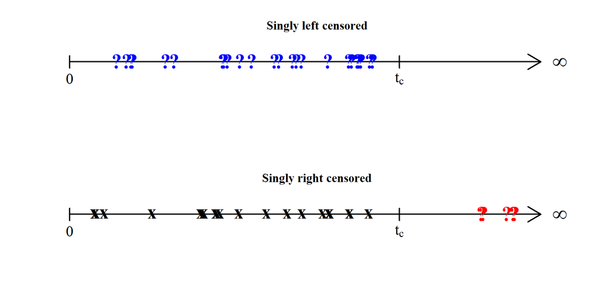

## Example 3.1 - Plant 1 Heat Exchanger Data

STAT 687 - Chapter 3

As discussed in Chapter 2, $\pi_{i}$ represents the multinomial probability that a failure will occur in interval $i$.

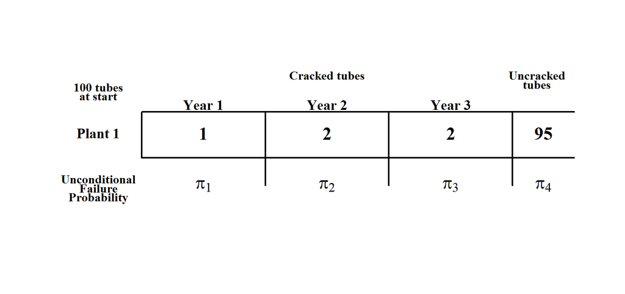

$\mathbf{\text{Likelihood: } = \mathcal{C}\times[\pi_{1}]^1\times[\pi_2]^2\times[\pi_3]^2\times[\pi_4]^{95}}$

## Example 3.1 - Plant 1 Heat Exchanger Data

STAT 687 - Chapter 3

```r
par(family="serif",font=2,bg=NA)
plot(NA,axes=FALSE,xlab="",ylab="",xlim=range(-50,350),ylim=range(-10,150))
segments( c(0,0,0,100,200,300),    c(50,100,50,20,20,20),
          c(350,350,0,100,200,300),c(50,100,100,100,100,100),
            lwd=c(rep(2,6)))
text(rep(-35,3),seq(27,127,50),c("Unconditional","Plant 1","100 tubes"),cex=c(1,1.15,1))
text(rep(-35,2),seq(17,117,100),c("Failure","at start"),cex=rep(1,2))
text(-35,6,"Probability",cex=1)
text(c(seq(50,250,100),325),rep(20,4),c(expression(pi[1]),expression(pi[2]),
                                        expression(pi[3]),expression(pi[4])),cex=1.5)
text(seq(50,250,100),rep(108,3),c("Year 1","Year 2","Year 3"),cex=rep(1.15,3))
text(c(150,320,320),c(rep(140,2),130),c("Cracked tubes", "Uncracked","tubes"),cex=rep(1,3))
text(c(seq(50,250,100),325),rep(77,4),c("1","2","2","95"),cex=rep(1.5,4))
```

## Example 3.1 - Plant 1 Heat Exchanger Data

STAT 687 - Chapter 3

Binomial method of estimating $F(t)$

- Envision that we inspect each heat exchanger tube
- Assign a value of $1$ if the tube has failed and value of $0$ if the tube has not failed
- This binary data treats each inspection as a series of observations from a Bernoulli RV
- The outcome (total number of $1's$ for an inspection) is then an observation from a Binomial distribution with parameter $p$
- A nonparametric estimator for the $F(t)$ is the binomial parameter $p$

## Example 3.1 - Plant 1 Heat Exchanger Data

STAT 687 - Chapter 3

As discussed in Chapter 2, $\pi_{i}$ represents the multinomial probability that a failure will occur in interval $i$.

Recall the binomial distribution with pmf

$F(x;p,n) = \left( \begin{array}{c} n \\ x \end{array} \right)(p)^{x}(1 - p)^{(n-x)} \;\;\;\;\;\; \mbox{for x = 0, 1, 2,..., n}$

where $\begin{aligned} x&\equiv \text{ the number of observed "successes" (failures in this case)}\\ n&\equiv \text{ the total sample size}\\ p&\equiv \text{ the true (but unknown) probability that a unit will fail}\\ \end{aligned}$ and

$\hat{p}_{_{MLE}}=\frac{x}{n}$

## Example 3.1 - Plant 1 Heat Exchanger Data

STAT 687 - Chapter 3

One way we can find the value of $\hat{F}(t)$ is by envisioning that we inspect each tube and assign a value of 1 if the tube has failed and value of 0 if the tube has not failed. By gathering this binary data we treat each inspection as an observation from a Bernoulli RV

Figure 3.1 shows censoring events occuring at the end of years 1,2, and 3

However, note that the nonparametric estimates for $F(t_{i})$ computed using the simple binomial method do not reduce the risk set after a failure

The binomial method treats each inspection as a separate analysis with singly censored data

- Analysis 1 $\rightarrow n=100, t_{0}=0, t_{c}=Year 1 \rightarrow$ 1 failure observed
- Analysis 2 $\rightarrow n=100, t_{0}=0, t_{c}=Year 2 \rightarrow$ 3 failures observed
- Analysis 3 $\rightarrow n=100, t_{0}=0, t_{c}=Year 3 \rightarrow$ 5 failures observed

Later, we’ll discuss the Kaplan-Meier estimator where the sample size does decrease when failures occur

## Example 3.1 - Plant 1 Heat Exchanger Data

STAT 687 - Chapter 3

The nonparametric estimate of $F(t_{i})$ based on the binomial distribution is

$\hat{F}(t_{i})=\frac{\#\text{ of failures up to time }t_i}{n}=\frac{\sum_{j=1}^{i}d_j}{n}$

$\begin{aligned} \text{where }n&\equiv \text{sample size}\\ d_{j}&\equiv \text{ the number of failures in interval } j\\ \end{aligned}$

For the Plant 1 data $\begin{aligned}\hat{F}(1)=1/100\\ \hat{F}(2)=3/100\\ \hat{F}(3)=5/100\\ \end{aligned}$

## Example 3.2 - Nonparametric Estimator of $F(t)$

STAT 687 - Chapter 3

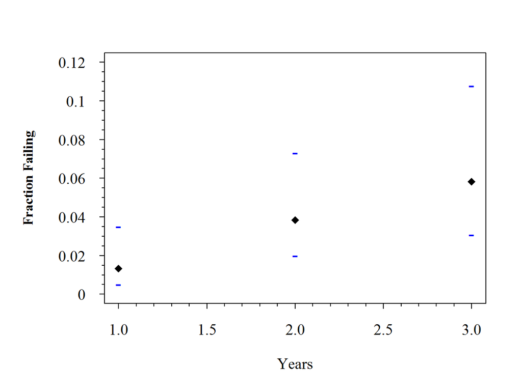

## Example 3.2 - Nonparametric Estimator of $F(t)$

STAT 687 - Chapter 3

```r
HeatExchanger.ld <- frame.to.ld(heatexchanger,
                                response.column = c(1,2),
                                censor.column = 3,
                                case.weight.column=4,
                                data.title = "Heat Exchanger Crack Data",
                                time.units = "Years")
plot(HeatExchanger.ld,band.type="Pointwise")
```

## $\S$ 3.2 - Estimation from singly censored data

STAT 687 - Chapter 3

Recall that the cdf $F(t)$ is defined everywhere in $\mathcal{R}$

But, if inspections occur in discrete intervals, $F(t)\in (t_{i-1},t_{i})$ may be unknown

- If no failures occur in $(t_{i-1},t_{i})$, we know $F(t_{i})$ is constant over interval $i$
- If one or more failures occur in $(t_{i-1},t_{i})$, we can estimate $F(t_{i})-F(t_{i-1})$ (binomial method)
  - **But we won’t know when the failures occured in the interval**

Convention for this text - there is insufficient information to assign a value of $\hat{F}(t)\in (t_{i-1},t_{i})$ for censored observations occuring between inspections

# Section 3.3|Basic Ideas Of Statistical Inference

## $\S$ 3.3.2 - Confidence intervals

STAT 687 - Chapter 3

Sampling error exists regardless of how we generate a random sample, but as sample size increases we expect our estimates of the properties of the sample approach the properties of the overall population that we are interested in making statements about.

In the heat exchanger example, if the number of tubes at each Plant 1 were 10 rather than 100, and we used the observations from Plant 1 as the basis for our estimate of the reliability for the overall population of heat exchanger tubes at every plant we should expect our estimate to have a lot more uncertainty.

Some of the tubes may experience higher usage. And if our sample of 10 tubes included several of these tubes might could conclude that the reliability of the tubes is lower than reality. By increasing the size of the sample we can more better account for any variability that may exist.

In inferential statistics, confidence intervals (CI) are useful for quantifying the uncertainy associated with a point estimate due to sampling errors

Sources of uncertainty

- Limited understanding of how a system interacts with its environment
- Manufacturing flaws & deviations between units in a sample
- Inability of chosen parametric model to fit data
- Small sample sizes amplify the uncertainty

## $\S$ 3.3.2 - Confidence intervals

STAT 687 - Chapter 3

What does it mean to say “…the $100\times(1-\alpha)\%$ CI for $\theta =(\underline{\hat{\theta}},\overline{\hat{\theta}})$…”

- For $\alpha=0.05 \rightarrow$ a $95\%$ CI on $\theta$ means
> - If an experiment were run $i$ times (each run producing a distinct data set) the true value of $\theta$ would be in $(\underline {\hat {\theta_{i}}},\overline{\hat{\theta_{i}}})$ in $95\%$ of the runs.
> - It does not mean $P(\underline{\hat{\theta_{i}}} <\theta<\overline{\hat{\theta_{i}}})=0.95$
> - This probability is $1$ or $0$ since $\theta$ is either in the interval or it isn’t

## What Does “Confidence Level” Mean? [source](https://homer.shinyapps.io/sim_tutorial_Rmd)

STAT 687 - Chapter 3

## $\S$ 3.3.2 - Exact CI vs Approximate CI

STAT 687 - Chapter 3

**Coverage probability**

- The actual proportion of runs that a $100\times (1-\alpha)\%$ CI will contain the true parameter value being estimated
- For confidence level $\alpha$, $1-\alpha$ is the **nominal** coverage probability

**Exact CI** - complete data and some censored data

- Based on the same distribution as that of the value being estimated
- Nominal coverage probability $=$ actual coverage probability

**Approximate CI** - majority of censored data

- Based on a different distribution than that of the value being estimated
- Nominal coverage probability $\ge$ actual coverage probability

# Section 3.4|Confidence Intervals From Complete or Singly Censored Data

## $\S$ 3.4.1 - Pointwise binomial-based CI for $F(t_i)$

STAT 687 - Chapter 3

$(\underline{F}(t_i),\overline{F}(t_i))=\left(1+\frac{(n-n\hat{F}+1)\mathcal{F}_{(1-\alpha/2,2n-2n\hat{F}+2,2n\hat{F})}}{n\hat{F}}\right)^{-1}, \left(1+\frac{n-n\hat{F}}{(n\hat{F}+1)\mathcal{F}_{(1-\alpha/2,2n\hat{F}+2,2n-2n\hat{F})}}\right)^{-1}$

Where $\mathcal{F}_{c;d_{1},d_{2}}$ is the value of the F-distribution quantile function at $1-c$ with $d_{1}$ and $d_{2}$ degrees of freedom.

- The presence of the F-distribution in (3.2) does not preclude the C-P interval from being exact
- Rather, the C-P interval is based on the relationship between the binomial and F distributions

## Example 3.3 - Binomial CI for $F(t_i)$

STAT 687 - Chapter 3

Using the Plant 1 heat exchanger data at $t_{i}=2 \rightarrow n=100, d=3, \alpha=0.05$

$\begin{aligned} (\underline{F}(t_i),\overline{F}(t_i))&=\left(1+\frac{(100-100\times\frac{3}{100}+1)\mathcal{F}_{(.975;200-6+2,6)}}{100\times \frac{3}{100)}}\right)^{-1}, \left(1+\frac{100-100\times\frac{3}{100}}{(100\times\frac{3}{100}+1)\mathcal{F}_{(.975;6+2,200-6)}}\right)^{-1}\\ &=(0.0062,0.0852) \end{aligned}$

```r
cp.ci<-function(n,d,a)  {
    Fhat<-d/n
    f1<-2*n-2*n*Fhat
    f2<-2*n*Fhat
    cp.lower<-(1+(n-n*Fhat+1)*qf(1-a/2,f1+2,f2)/(n*Fhat))^-1
    cp.upper<-(1+(n-n*Fhat)/((n*Fhat+1)*qf(1-a/2,f2+2,f1)))^-1
return(c(cp.lower,cp.upper))  }
```

```
## [1] 0.006229972 0.085176053
```

## $\S$ 3.4.2 - Pointwise Normal-approx CI for $F(t_i)$

STAT 687 - Chapter 3

Approach used most often in this course for computing CI for $F(t_{i})$

Assumes the sampling errors are normally distributed WRT the binomial point estimate, that is

$Z_{\hat{F}}=\frac{\hat{F}(t_i)-F(t_i)}{\hat{se}_{\hat{F}}}\xrightarrow d N(0,1) \text{ as } n\rightarrow\infty$

$F(t_{i}) \hspace{114pt} \text{the true (but unknown) value}$

$\hat{F}(t_{i})=\sum_{j=1}^{i}d_{i}/n \hspace{57pt} \text{the binomial point estimate}$

$\hspace{6pt}\hat{se}_{\hat{F}}=\sqrt{\hat{F}(t_{i})[1-\hat{F}(t_{i})]/n} \hspace{10pt} \text{ the binomial standard errors}$

## Example 3.4 - Normal-approx CI for Plant 1 $F(t_i)$

STAT 687 - Chapter 3

Consider again the heat exchanger data for Plant 1

At the end of Year 3, five failures were observed thus

$\widehat{F}(3)=\frac{5}{100}=0.05 \;\;\;\text{and}\;\;\; \widehat{se}_{\hat{F}(3)}=\sqrt{\frac{.05(1-.05)}{100}}=.02179$

The $95\%$ CI for $F(3)$ using the normal approximation is then

$[\underline{F(3)}, \overline{F(3)}]=.05\pm F^{-1}_{_{NOR}}(P = 0.975)\times .02179 = [.0073,.0927]$

Where

$F^{-1}_{_{NOR}}(P = .975)\equiv z_{.975}\equiv$ `qnorm(.975)`

## Example 3.4 - Normal-approx CI for Plant 1 $F(t_i)$

STAT 687 - Chapter 3

## Example 3.5 - Integrated Circuit Life Test Data

STAT 687 - Chapter 3

As the number of inspections increase, the interval widths $(t_{i-1},t_{i}]$ approach zero

**Integrated circuit life test data**

$n=4156$ Integrated circuits

$d=28$ Exact failure times

We dont know how the circuits are tested, just that 28 failures were observed before the test was stopped at 1370 hours.

The presence of ties is a clear indication that this is grouped read-out data as defined in Chapter 1 and the failures were discovered at periodic inspections.

The inspection interval may have been .05 hours at the beginning of the test and then extended as the test progressed.

```
##      Hours   Status Weight
## 1     0.10  Failure      2
## 2     0.15  Failure      1
## 3     0.60  Failure      1
## 4     0.80  Failure      2
## 5     1.20  Failure      1
## 6     2.50  Failure      1
## 7     3.00  Failure      1
## 8     4.00  Failure      2
## 9     6.00  Failure      1
## 10   10.00  Failure      2
## 11   12.50  Failure      1
## 12   20.00  Failure      2
## 13   43.00  Failure      2
## 14   48.00  Failure      2
## 15   54.00  Failure      1
## 16   74.00  Failure      1
## 17   84.00  Failure      1
## 18   94.00  Failure      1
## 19  168.00  Failure      1
## 20  263.00  Failure      1
## 21  593.00  Failure      1
## 22 1370.00 Censored   4128
```

## Example 3.5 - Integrated Circuit Life Test Data

STAT 687 - Chapter 3

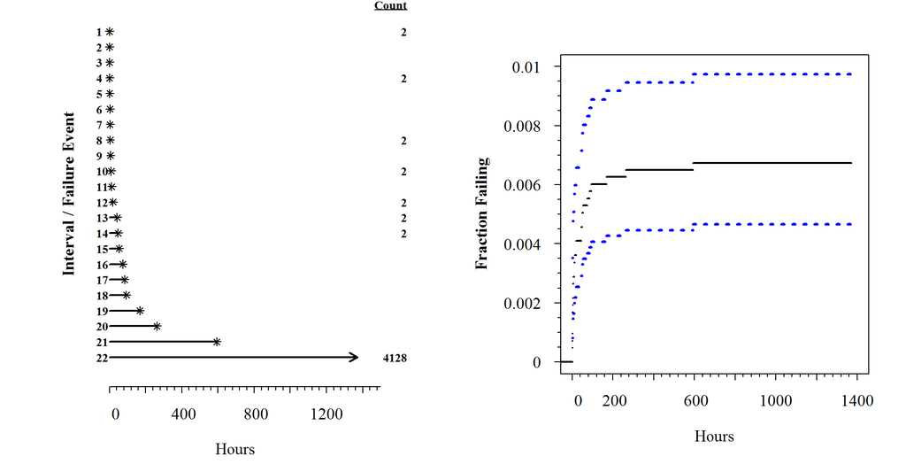

## Example 3.5 - Integrated Circuit Life Test Data

STAT 687 - Chapter 3

```r
par(family="serif",font=2,bg=NA,mfrow=c(1,2))
lfp1370.ld<- frame.to.ld(lfp1370,
                         response.column = 1,
                         censor.column = 2,
                         case.weight.column=3,
                         data.title = "Integrated Circuit Failure Data",
                         time.units = "Hours")
event.plot(lfp1370.ld)
plot(lfp1370.ld)
par(mfrow=c(1,1))
```

# Section 3.5|Estimation From Multiply Censored Data

## $\S$ 3.5 - Estimation from multiply censored data

STAT 687 - Chapter 3

In multiply right-censored data, more than one censoring event occurs

Multiple censoring results when:

- Items are removed from the test to fill a real-world need
- Items enter the test at different times
- An error affects some of the items after testing begins
- An item fails due to a failure mode that is not of interest

**Basic idea:** The population of at-risk units changes, but not due to the cause of interest in the study

**Example:** Pooling the observations from all three plants in the heat exchanger data

## Figure 3.4 - Pooled heat exchanger data

STAT 687 - Chapter 3

The pooled data set has an initial sample size of 300 tubes. At the end of year one, 4 tubes have failed across all of the plants. Since plant 3 was only in operation for 1 year we don’t know when the 99 tubes functioning tubes would have failed, but they must be removed from the risk set.

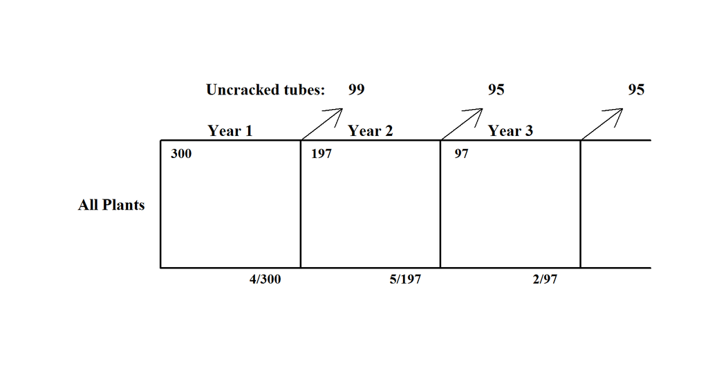

## Figure 3.4 - - Pooled heat exchanger data

STAT 687 - Chapter 3

```r
par(family="serif",font=2,bg=NA)
plot(NA,axes=FALSE,xlab="",ylab="",xlim=range(-50,350),ylim=range(-10,150))
segments( c(0,0,0,100,200,300),c(0,100,0,0,0,0),
          c(350,350,0,100,200,300),c(0,100,100,100,100,100),
            lwd=c(rep(2,6)))
text(-35,50,"All Plants",cex=1.15)
text(seq(75,275,100),rep(-8,3),c("4/300","5/197","2/97"))
text(seq(50,250,100),rep(108,3),c("Year 1","Year 2","Year 3"),cex=rep(1.15,3))
text(seq(140,340,100),rep(140,3),c("99","95","95"),cex=rep(1.15,3))
text(seq(15,215,100),rep(90,3),c("300","197","97"),cex=rep(1,3))
text(75,140,"Uncracked tubes:",cex=1.15)
arrows(seq(100,300,100),rep(100,3),seq(130,330,100),rep(125,3),length=rep(0.25,3))
```

## $\S$ 3.5 - Estimation from multiply censored data

STAT 687 - Chapter 3

For singly censored data, $F(t_{i})$ was estimated assuming $n$ was constant

For multiple censored data, the number of units at risk in $(t_{i-1},t_{i}]$ is expressed as

$n_{i}=n-\sum_{j=0}^{i-1}d_{j}-\sum_{j=0}^{i-1}r_{j}, i=1,...,m$

where

- $d_{j} \equiv$ the number of failed units in interval $j, j=0,...,i-1$
- $r_{j} \equiv$ the number of censored units in interval $j, j=0,...,i-1$
- $m \equiv$ the number of intervals (need not be of equal length)

## $\S$ 3.5 - Estimation From Multiply Censored Data

STAT 687 - Chapter 3

It follows that $\hat{p}_{i}$ (the conditional probability that a unit will fail in interval $i$, given that it has survived each of the previous intervals) is expressed as

$\hat{p}_{i}=\frac{d_{i}}{n_{i}}, i=1,...,m$

And

$\hat{S}(t_{i})=\prod_{j=1}^{i}\left[1-\hat{p_{j}}\right], i=1,...,m$

$\hat{F}(t_{i})=1-\hat{S}(t_{i})=1-\prod_{j=1}^{i}\left[1-\hat{p_{j}}\right], i=1,...,m$

## Fig 1.7 - Heat exchanger crack inspection data

STAT 687 - Chapter 3

[figure not shown]

## Table 3.2 - Pooled Heat Exchanger Data

STAT 687 - Chapter 3

$\begin{array}{lrrrrllrr} \hline Year & t\_i & d\_i & r\_i & n\_i & p\_i & 1-p\_i & S(t\_i) & F(t\_i) \\ \hline (0-1] & 1 & 4 & 99 & 300 & 4/300 & 296/300 & 0.9867 & 0.0133 \\ (1-2] & 2 & 5 & 95 & 197 & 5/197 & 192/197 & 0.9616 & 0.0384 \\ (2-3] & 3 & 2 & 95 & 97 & 2/97 & 95/97 & 0.9418 & 0.0582 \\ \hline \end{array}$

Pooling the data assumes the usage pattern is consistent across all three plants

If this is a valid assumption, then the “test” begins with an sample set of 300 tubes

# Section 3.6|Pointwise Confidence Intervals From Multiply Censored Data

## $\S$ 3.6 - Pointwise CI from multiply censored data

STAT 687 - Chapter 3

For multiply censored data, no method exists to compute exact CI’s

We must rely on normal approximations

In general, the normal approximation will be of the form

$Z_{\hat{F}}=\frac{\hat{F}(t_{i})-F(t_{i})}{\hat{se}_{\hat{F}}}$

Computing the standard error term will require the Delta Method

**By the end of this course you should know the Delta Method in your sleep**

## The Delta Method

STAT 687 - Chapter 3

1. Suppose we know how to estimate the variance of $\mathbf{\hat{\theta}}=\hat{\theta}_{1},...,\hat{\theta}_{r}$
2. We want to estimate the variance of some function of $\mathbf{\theta}$, say $g(\mathbf{\hat{\theta}})$
3. If we can find $\frac{dg(\theta)}{d\theta}$, the Delta Method can help us find $\widehat{Var}[g(\mathbf{\hat{\theta}})]$ from $\widehat{Var}[\mathbf{\hat{\theta}}]$

The general Delta Method equation, given in (B.3) is

$Var\left[g(\hat{\theta})\right]\approx \sum_{i=1}^{r} \left[\frac{\partial g(\mathbf{\theta})}{\partial \theta_{i}}\right]^{2} Var(\hat{\theta_{i}})+\sum_{i=1}^r \mathop{\sum^{r}_{j=1}}_{i\ne j}\left[\frac{\partial g(\mathbf{\theta})}{\partial \theta_{i}}\right]\left[\frac{\partial g(\mathbf{\theta})}{\partial \theta_{j}}\right] Cov(\hat{\theta}_{i}, \hat{\theta}_{j})$

## $\S$ 3.6.1 - Approximate Variance of $\hat{F}(t_{i})$

STAT 687 - Chapter 3

Since $\hat{F}(t_{i})=1-\hat{S}(t_{i})$, we know that $Var[\hat{F}(t_{i})]=Var[\hat{S}(t_{i})]$

Similarly, $\hat{q}=1-\hat{p}$ and $Var[\hat{q}]=Var[\hat{p}]$

Using the Delta Method where $\theta=q_j$ and $g(\theta)=S(t_i)$ results in

$\displaystyle \hat{S}(t_{i})\approx S(t_i)+ \sum_{j=1}^{i}\frac{\partial S}{\partial q_{j}}\vert_{q_{j}}(\hat{q}_{j}-q_{j})$

Here is where I could say something snarky, like

“…it follows that $Var[\hat{S}(t_{i})]$ is given by equation 3.8”

> **But, I won’t…**

## $\S$ 3.6.1 - Approximate Variance of $\hat{F}(t_{i})$

STAT 687 - Chapter 3

To use the Delta Method we must first ensure that we know 4 things

1. **The parameter - $\theta$**
2. **The function of the parameter - $f(\theta)$**
3. **The partial derivatives - $\frac{\partial f(\theta)}{\partial \theta_{i}}, \;\; i=1,...m$**
4. **The parameter variance - $Var[\theta]$**

## For Equation 3.8

STAT 687 - Chapter 3

**What is $\theta$?**

$p_{i} \;\;\;\text{or}\;\;\;q_{i}$

**What is $f(p)$**?

$\begin{aligned} S(t_{i})&=\prod_{j=1}^{i}[1-p_{j}], i=1,...,m \\ &=(1-p_{1})(1-p_{2})...(1-p_{i})\\ &=(q_{1})(q_{2})...(q_{i}) \end{aligned}$

## For Equation 3.8

STAT 687 - Chapter 3

**What is $\frac{\partial S(t_{i})}{\partial q_{i}}, \;\; i=1,...m$**?

$\forall i \in 1,2,...m$

$\begin{aligned} \frac{\partial S(t_{i})}{\partial q_{i}}&=\frac{\partial \left( q_{1}q_{2}...q_{i-1}q_{i}\right)}{\partial q_{i}}\\\\\\ &=q_{1}q_{2}...q_{i-1}\\\\\\ &=\frac{S(t_{i})}{q_{i}}\\ \end{aligned}$

## For Equation 3.8

STAT 687 - Chapter 3

**What is $Var(p)$?**

- Since $q_{j}=1-p_{j}$, we know that $Var[q_{j}]=Var[p_{j}]$
- Recall that $\hat{p}=\frac{x}{n}$ where $x$ is the number of observed “successes”
- Also, note that $\hat{p}$ is an unbiased estimator for $p$

$E[\hat{p}]=E\left[\frac{x}{n}\right]=\frac{E[x]}{n}=\frac{np}{n}=p$

## For Equation 3.8

STAT 687 - Chapter 3

**What is $Var(p)$?**

Since $\hat{p}$ is an unbiased estimator for $p$,

$\begin{aligned} Var[\hat{p}]&=Var[p]\\\\ &=Var\left[\frac{x}{n}\right]=\frac{1}{n^{2}}Var[x]=\frac{Var[x]}{n^{2}}\\\\\\ &=\frac{np(1-p)}{n^{2}}=\frac{p(1-p)}{n}\\ \end{aligned}$

## Putting Everything Together

STAT 687 - Chapter 3

$\begin{aligned} Var[S(t_{i})]&=\sum_{j=1}^{i}\left[\frac{\partial S(t_{i})}{\partial q_{j}}\right]^{2}Var(q_{j})\\ &=\sum_{j=1}^{i}\left[\frac{S(t_{i})}{q_{j}}\right]^{2}\frac{p_{j}(1-p_{j})}{n_{j}}\\ &=S(t_{i})^{2}\sum_{j=1}^{i}\frac{p_{j}(1-p_{j})}{n_{j}(1-p_{j})^{2}}\\ &=S(t_{i})^{2}\sum_{j=1}^{i}\frac{p_{j}}{n_{j}(1-p_{j})}\\ \end{aligned}$

## $\S$ 3.6.2 - Greenwood’s formula

STAT 687 - Chapter 3

Substituting the estimated values into (3.8) gives what is known as Greenwood’s formula

$\displaystyle \widehat{Var}\left[\hat{F}(t_{i})\right]=\widehat{Var}\left[\hat{S}(t_i)\right]=\left[\hat{S}(t_{i})\right]^{2}\sum_{j=1}^{i}\frac{\hat{p}_{j}}{n_{j}(1-\hat{p_{j}})}$

Greenwood’s formula can then be used to estimate the standard error of $\hat{F}(t_{i})$ as

$\hat{se}_{\hat{F}}=\sqrt{\widehat{Var}[\hat{F}(t_{i})]}$

## $\S$ 3.6.3 Pointwise Normal-approx CI for $F(t_i)$

STAT 687 - Chapter 3

The pointwise $1-\alpha$ confidence intervals for multiply censored data are then expressed as

$\left[\underline{F}(t_i),\overline{F}(t_i)\right]=\hat{F}(t_i)\pm z_{(1-\alpha/2)}\hat{se}_{\hat{F}}$

Under the assumption that for large sample sizes

$Z_{\hat{F}}=\frac{\hat{F}(t_i)-F(t_i)}{\hat{se}_{\hat{F}}}\xrightarrow d N(0,1) \text{ as } n\rightarrow\infty$

However, for small sample sizes, this assumption may fail if the distribution of $Z_{\hat{F}}$ is highly skewed

## $\S$ 3.6.3 Pointwise Normal-approx CI for $F(t_i)$

STAT 687 - Chapter 3

A better approximation for $\hat{F}(t_{i})$ results from a logit transformation such that

$Z_{\text{logit}(\hat{F})}=\frac{\text{logit}(\hat{F}(t_i))-\text{logit}(F(t_i))}{\hat{se}_{\text{logit}(\hat{F})}}$

The transformed pointwise $1-\alpha$ CI for multiply censored data are then

$\left[\underline{\underline{F}}(t_i),\overline{\overline{F}}(t_i)\right]=\left[\frac{\hat{F}(t_i)}{\hat{F}(t_i)+(1-\hat{F}(t_i)\times w}, \frac{\hat{F}(t_i)}{\hat{F}(t_i)+(1-\hat{F}(t_i)/ w}\right]$

where $w=\exp\left[\frac{z_{(1-\alpha/2)}\hat{se}_{\hat{F}}}{\hat{F}(1-\hat{F})}\right]$

## Example 3.7 - CI for Pooled Heat Exchanger Data

STAT 687 - Chapter 3

Recall Table 3.2

$\begin{array}{lrrrrllrr} \hline Year & t\_i & d\_i & r\_i & n\_i & p\_i & 1-p\_i & S(t\_i) & F(t\_i) \\ \hline (0-1] & 1 & 4 & 99 & 300 & 4/300 & 296/300 & 0.9867 & 0.0133 \\ (1-2] & 2 & 5 & 95 & 197 & 5/197 & 192/197 & 0.9616 & 0.0384 \\ (2-3] & 3 & 2 & 95 & 97 & 2/97 & 95/97 & 0.9418 & 0.0582 \\ \hline \end{array}$

Therefore

$\begin{aligned} \widehat{Var}(1)&=[\hat{S}(t_{i})]^{2}\sum_{j=1}^{i}\left[\frac{\hat{p}_{j}}{n_{j}(1-p_{j})}\right]\\ &=(.9867)^{2}\left[\frac{.0133}{300(.9867)}\right]\\ &=.0000438 \end{aligned}$

## Example 3.7 CI for Pooled Heat Exchanger Data

STAT 687 - Chapter 3

The estimated standard error is then found by $\widehat{se}_{\hat{F}}=\sqrt{.0000438}=.00662$

And the $95\%$ pointwise CI is

$\left[\underline{F}(1),\overline{F}(1)\right]=.0133\pm 1.960\times .00662=[.0003, .0263]$

Applying the logit transformation to $\hat{F}(t_{i})$ gives

$\begin{aligned} \left[\underline{\underline{F}}(1),\overline{\overline{F}}(1)\right]&=\left[\frac{.0133}{.0133+(1-.0133)\times 2.6878}, \frac{.0133}{.0133+(1-.0133)/ 2.6878}\right]\\\\\\ &=[.0050, .0350]\\\\ \end{aligned}$

## Example 3.7 CI for Pooled Heat Exchanger Data

STAT 687 - Chapter 3

A table of values for $\hat{F}(t_{i})$ can be produced from the meekR package using

```r
print(cdfest(HeatExchanger.ld))$table
```

```
##      Years-lower Years-upper       Fhat     SE_Fhat   95% Lower  95% Upper
## [1,]           1           1 0.01333333 0.006622073 0.005013243 0.03497624
## [2,]           2           2 0.03837562 0.012802116 0.019818170 0.07301557
## [3,]           3           3 0.05820292 0.018700629 0.030694112 0.10762830
```

This output may then be converted to a $LaTeX$ table using

```r
xtable::xtable(print(cdfest(HeatExchanger.ld))$table, include.rownames = FALSE, digits = c(0,0,0,5,5,5,5))
```

$\begin{array}{rrrrrr} \hline Years-lower & Years-upper & Fhat & SE\_Fhat & 95\% Lower & 95\% Upper \\ \hline 1 & 1 & 0.01333 & 0.00662 & 0.00501 & 0.03498 \\ 2 & 2 & 0.03838 & 0.01280 & 0.01982 & 0.07302 \\ 3 & 3 & 0.05820 & 0.01870 & 0.03069 & 0.10763 \\ \hline \end{array}$

# Section 3.7|Estimation From Multiply Censored Data With Exact Failures

## Multiply Censored Data With Exact Failures

STAT 687 - Chapter 3

“Exact” failures are an abstraction, but can be considered to have occurred if

- Test units are under continuous inspection (some electronic systems)
- A large number of inspections are performed at closely spaced intervals

In a test with exact failures, most inspections will not discover a failure, therefore

- The value of $F(t)$ will not change
- The plot of $\hat{F}(t)$ will appear as a step-function

## Example 3.9 - Shock Absorber Data

STAT 687 - Chapter 3

```r
DT::datatable(shockabsorber, rownames = FALSE)
```

| Distance | Mode | Censor |
| --- | --- | --- |
| 6700 | Mode1 | Failure |
| 6950 | Censored | Censored |
| 7820 | Censored | Censored |
| 8790 | Censored | Censored |
| 9120 | Mode2 | Failure |
| 9660 | Censored | Censored |
| 9820 | Censored | Censored |
| 11310 | Censored | Censored |
| 11690 | Censored | Censored |
| 11850 | Censored | Censored |

[output cut: 28 more lines]

## Table 3.4

STAT 687 - Chapter 3

| km | Failed | Censored | Entered | p | q | S(t) | F(t) |
| --- | --- | --- | --- | --- | --- | --- | --- |
| 6700 | 1 | 0 | 38 | 1/38 | 37/38 | 0.9737 | 0.0263 |
| 6950 | 0 | 1 | 37 |  |  | 0.9737 | 0.0263 |
| 7820 | 0 | 1 | 36 |  |  | 0.9737 | 0.0263 |
| 8790 | 0 | 1 | 35 |  |  | 0.9737 | 0.0263 |
| 9120 | 1 | 0 | 34 | 1/34 | 33/34 | 0.9451 | 0.0549 |
| 9660 | 0 | 1 | 33 |  |  | 0.9451 | 0.0549 |
| 9820 | 0 | 1 | 32 |  |  | 0.9451 | 0.0549 |
| 11310 | 0 | 1 | 31 |  |  | 0.9451 | 0.0549 |
| 11690 | 0 | 1 | 30 |  |  | 0.9451 | 0.0549 |
| 11850 | 0 | 1 | 29 |  |  | 0.9451 | 0.0549 |

[output cut: 3 more lines]

## Table 3.4

STAT 687 - Chapter 3

```r
t<-c(6700,6950,7820,8790,9120,9660,9820,11310,11690,11850,11880,12140,12200)
d<-c(1,0,0,0,1,0,0,0,0,0,0,0,1)
r<-c(0,1,1,1,0,1,1,1,1,1,1,1,0)
n<-c(38,37,36,35,34,33,32,31,30,29,28,27,26)
p<-c("1/38","","","","1/34","","","","","","","","1/26")
q<-c("37/38","","","","33/34","","","","","","","","25/26")
S<-c(rep(.9737,4),rep(.9451,8),.9087)
D<-c(rep(.0263,4),rep(.0549,8),.0913)
###<b>
Table.3.4<-data.frame(t,d,r,n,p,q,S,D)
DT::datatable(Table.3.4,
          options = list(iDisplayLength = 7),
          rownames=FALSE,
          colnames=c("km","Failed","Censored","Entered","p","q","S(t)","F(t)"))
###</b>
```

## Example 3.9 - Shock Absorber Data Set

STAT 687 - Chapter 3

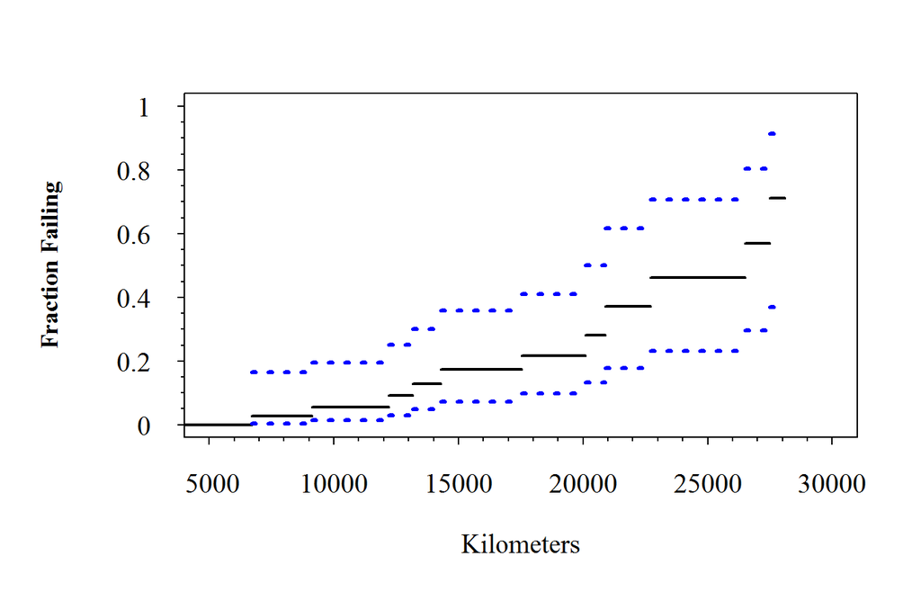

```r
ShockAbsorber.ld <- frame.to.ld(shockabsorber, response.column = 1, censor.column = 3,
data.title = "Shock Absorber Failure Data",time.units = "Kilometers")
plot(ShockAbsorber.ld,band.type="Pointwise")
```

## Example 3.9 - Shock Absorber Data Set

STAT 687 - Chapter 3

$\begin{array}{rrrrrr} \hline Kilometers-lower & Kilometers-upper & Fhat & SE\_Fhat & 95\% Lower & 95\% Upper \\ \hline 0 & 6700 & 0.00000 & 0.00000 & 0.00000 & 0.00000 \\ 6700 & 9120 & 0.02632 & 0.02597 & 0.00369 & 0.16457 \\ 9120 & 12200 & 0.05495 & 0.03783 & 0.01376 & 0.19513 \\ 12200 & 13150 & 0.09130 & 0.05093 & 0.02929 & 0.25073 \\ 13150 & 14300 & 0.12916 & 0.06128 & 0.04851 & 0.30143 \\ 14300 & 17520 & 0.17271 & 0.07205 & 0.07210 & 0.35933 \\ 17520 & 20100 & 0.21625 & 0.08034 & 0.09826 & 0.41130 \\ 20100 & 20900 & 0.28156 & 0.09661 & 0.13321 & 0.49984 \\ 20900 & 22700 & 0.37137 & 0.11918 & 0.17844 & 0.61638 \\ 22700 & 26510 & 0.46117 & 0.13171 & 0.23246 & 0.70749 \\ 26510 & 27490 & 0.56894 & 0.14281 & 0.29656 & 0.80515 \\ 27490 & 28100 & 0.71262 & 0.15109 & 0.36869 & 0.91327 \\ \hline \end{array}$

# Section 3.8|Simultaneous Confidence Bands

## $\S$ 3.8.1 - Motivation

STAT 687 - Chapter 3

*Pointwise confidence intervals* $(\S \;\;\text{3.6.3})$

- Quantify the sampling uncertainty about $F(t_{i}$ at a set of individual points
- Have a collective coverage probability that is less than that any individual interval

*Simultaneous confidence intervals*

- Quantify the sampling uncertainty along the entire range of $F(t_{i})$
- Are generally wider than pointwise confidence intervals
- More accurately reflects the uncertainty over the displayed time range
- Should be used with the logit transformation

## Simultaneous & Pointwise CI’s

STAT 687 - Chapter 3

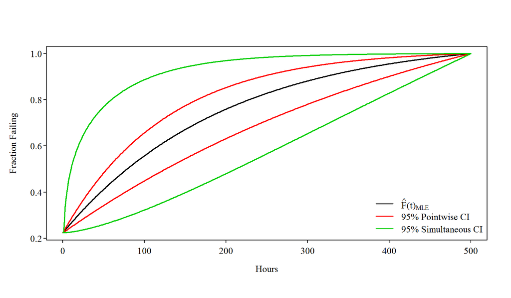

## $\S$ 3.8.2 - Large-Sample Simultaneous CI for $F(t)$

STAT 687 - Chapter 3

An approximate $100(1-\alpha)\%$ simultaneous CI for $F(t)$ is obtained from

$\left[\underline{\underline{F}}(t),\overline{\overline{F}}(t)\right]=\hat{F}(t)\pm (e_{a,b,1-\alpha/2)}\hat{se}_{\hat{F}(t)}, \;\;\; \forall t\in [t_{L}(a), t_{U}(b)]$

where the range $[t_{L}(a), t_{U}(b)]$ is a function of the censoring pattern in the data

Note that $e_{a,b,1-\alpha/2)}$ replaces

$\left[\underline{\underline{F}}(t),\overline{\overline{F}}(t)\right]=\left[\frac{\hat{F}(t)}{\hat{F}(t)+[1-\hat{F}(t)]\times w},\frac{\hat{F}(t)}{\hat{F}(t)+[1-\hat{F}(t)]/w}\right]$

## Table 3.5 - Factors for Simultaneous CI

STAT 687 - Chapter 3

$\begin{array}{rrrrrr} \hline a & b & .80 & .90 & .95 & .99 \\ \hline 0.00 & 0.99 & 2.86 & 3.12 & 3.36 & 3.85 \\ 0.01 & 0.99 & 2.84 & 3.10 & 3.34 & 3.83 \\ 0.05 & 0.99 & 2.76 & 3.03 & 3.28 & 3.77 \\ 0.10 & 0.99 & 2.72 & 3.00 & 3.25 & 3.75 \\ 0.00 & 0.99 & 2.84 & 3.10 & 3.34 & 3.83 \\ 0.01 & 0.99 & 2.81 & 3.07 & 3.31 & 3.81 \\ 0.05 & 0.99 & 2.73 & 3.00 & 3.25 & 3.75 \\ 0.10 & 0.99 & 2.68 & 2.96 & 3.21 & 3.72 \\ 0.00 & 0.95 & 2.76 & 3.03 & 3.28 & 3.77 \\ 0.01 & 0.95 & 2.73 & 3.00 & 3.25 & 3.75 \\ 0.05 & 0.95 & 2.62 & 2.91 & 3.16 & 3.68 \\ 0.10 & 0.95 & 2.56 & 2.85 & 3.11 & 3.64 \\ 0.00 & 0.90 & 2.72 & 3.00 & 3.25 & 3.75 \\ 0.01 & 0.90 & 2.68 & 2.96 & 3.21 & 3.72 \\ 0.05 & 0.90 & 2.56 & 2.85 & 3.11 & 3.64 \\ 0.10 & 0.90 & 2.48 & 2.79 & 3.06 & 3.59 \\ \hline \end{array}$

## $\S$ 3.8.3 - Time range for Simultaneous CI for $F(t)$

STAT 687 - Chapter 3

# Section 3.9|Uncertain Censoring Times

# Section 3.10|Arbitrary Censoring